# Day 3: Density regressions and implications for Morocco

ECU Summer School of Economic Complexity. UM6P Rabat. Afternoon Session 3.

Continuing from yesterday - density ranks how near each product sits to your country's basket, and we were careful not to claim more: whether nearby products actually get entered is an empirical question. Today we run that empirical test.

The steps: compute density from an earlier year so that it is measured before the outcome, fit the cross-section to see how much of the world's current export pattern density alone can explain, mark which products each country entered since then, test whether entry concentrates where density was high, and read the results the way you would defend them in front of a senior policymaker.

`COUNTRY`, `COMPARATORS`, and the two years at the top drive everything. On Google Colab, save your own copy before anything else: File menu, "Save a copy in Drive".

## 0. Setup

Same data packet as Days 1 and 2, nothing new to download. Two new tools join `ecomplexity`: `pyfixest` runs regressions with fixed effects, and `maketables` turns fitted models into a readable table.

## 1. Compute complexity metrics in a function

Today we need the whole Day 2 pipeline at several points in time, so we wrap it in a function of the year: export matrix, RCA, the continuous M-hat, and one package call that returns all the measures. Nothing in the body is new.

**Stuck? Reveal a hint (then a fuller hint).**

Hint 1. Yesterday's fix-the-bug: without this argument the package treats the weights as raw export values, recomputes RCA, and binarizes. The self-check below catches exactly that.

Hint 2. The docstring says presence_test="manual" means M_cp is taken as given from the value column. So `presence_rule = "manual"`.

## 2. Rewind to the earlier year

A prediction has to be made before the outcome. If we scored products by density today and then checked which products are in today's basket, that would be circular. So the whole pipeline runs again for an earlier year, and everything we use as a predictor comes from there. Before running the next cell, make a guess: was your country's basket bigger or smaller eleven years ago, and which of its flagship exports today were not yet competitive then?

Explore the data and check your guess

## 3. The cross-section: density fits the world as it is

Before asking whether density predicts change, the morning's two-stage approach asks a simpler question first: how much of the world's export pattern, as it stands, does density explain? This is the cross-sectional regression from Lecture 5, run on one year of data: the log of RCA against the log of relatedness density - each row represents one country and product. The lecture's table adds a second regressor built from the "country space" (countries like you export this product); we stay with the product space density you built yesterday, which carries most of the fit on its own.

|  | RCA (log), 2012 (1) |
| --- | --- |
| coef |  |
| Product space density (log) | 1.564*** (0.056) |
| Intercept | 0.566*** (0.080) |
| stats |  |
| Observations | 112,396 |
| R<sup>2</sup> | 0.249 |

Cross-section of country-product cells with positive exports. Standard errors clustered by country.

Density explains a visible share of who exports what, before any country or product adjustment and with only revealed co-location as input, which is why the lecture treats it as a summary of a country's productive ecosystem. This regression also cannot answer the question we actually care about, because in a single year density and RCA are two views of the same matrix. The real test is dynamic, and everything that follows sets it up.

## 4. Mark entries and exits

An entry is a product the country did not export competitively at the start of the window but does at the end. This is one boolean line, and it is the object every regression today explains. Exits are the mirror image, and they matter just as much: baskets churn, and a serious analysis counts both directions.

There are many ways to mark entries and exits, but this is the most intuitive: a cell is an entry when the country was NOT in the product at the start of the window but is in it at the end. In practice, you would have a more sophisticated definition.

**Stuck? Reveal a hint (then a fuller hint).**

Hint 1. You need cells that are False in mcp0 and True in mcp1. Boolean DataFrames combine elementwise, exactly like the matrices on Day 1.

Hint 2. `~mcp0` flips the start-of-window matrix, so `~mcp0 & mcp1` is True exactly where a product was absent then and present now.

## 5. Test table + find the bug

### Fix the broken cell

The cell below assembles everything into one regression table: one row per country and product, with the outcome events and the density score. As shipped, it fills the density column from `YEAR_T1`, the same year the outcome is measured. That version runs without an error and produces a strong-looking result, and it is wrong: entering a product mechanically raises the density around it, so measuring density after the fact bakes the answer into the question. Repair the cell so density comes from `YEAR_T0`, the year before any of the outcomes happened.

**Stuck? Reveal a hint (then a fuller hint).**

Hint 1. The self-check compares your density column against the package output for `YEAR_T0`. If it fails, your column still holds `YEAR_T1` values.

Hint 2. Replace `dens_t1` with `dens_t0` in the last assignment, keeping the same `.reindex(key).values` pattern so the rows stay aligned.

## 6. The Principle of Relatedness

The morning stated the principle: economies diversify preferentially into activities related to what they already do. Before any regression, look at it raw. Split the candidate products (no RCA at t0) into ten equal groups by their t0 density and compute the share of each group that had been entered by t1.

### Predict before running

How much more often does the top density decile get entered compared with the bottom decile: about 3x, about 12x, or about 30x? Commit to a number before running the cell.

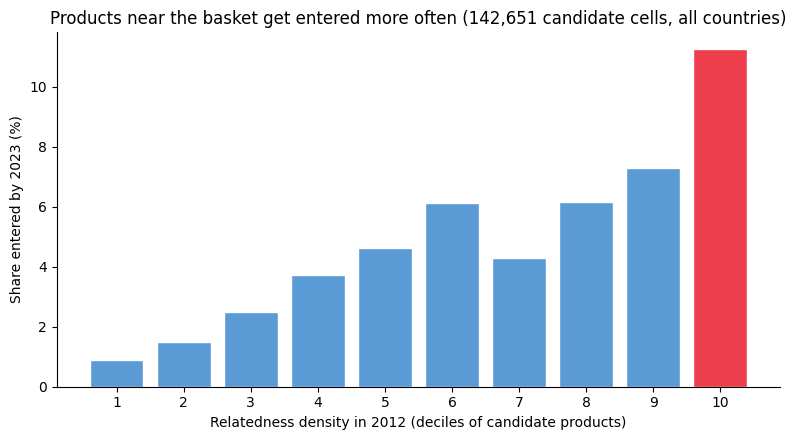

**Stuck? Reveal a hint (then a fuller hint).**

Hint 1. `cand` already has a decile column. You want, within each decile, the average of `appeared`.

Hint 2. `cand.groupby("decile")["appeared"].mean()` returns exactly the ten rates, indexed by decile.

This is the same figure the Principle of Relatedness literature shows for products, industries, technologies, and research areas, drawn from your own pipeline. The gradient is real, and it is also not yet a regression: rich diversified countries enter more products everywhere, and popular products get entered by everyone. The next section accounts for both.

## 7. Density regressions

The bar chart pools everything, so part of its gradient could just be that diversified countries enter more and common products attract everyone. The fix is fixed effects. A country fixed effect absorbs everything constant about the country in this window (size, income, how many products it enters overall), and a product fixed effect absorbs everything constant about the product (how entry-prone it is worldwide). What survives is within-country, within-product variation: is the same country more likely to enter a product when it sits closer to its basket than the country's overall entry activity and the product's overall popularity would predict?

We run four regressions on the same table. Entry appears twice, once pooled (no fixed effects, so it is the bar chart in one number) and once within (both fixed effects on). The entry and exit columns are linear probability models, ordinary regressions on a 0/1 outcome, so each coefficient reads directly as a change in probability. Note that in practice, you would use logit / probit models. Exit and export growth follow with fixed effects, and both control for the initial export level: a product a country barely exports is easier to lose, and small export lines grow faster mechanically. Growth is measured on the intensive margin, meaning how much existing export lines grew as opposed to new ones appearing, for cells that already exported something at t0, transformed with asinh, which behaves like a log but tolerates collapses to zero. Standard errors are clustered by country, since outcomes within a country move together. Entry has no initial-level control on purpose, since a product you do not yet make has no meaningful initial value.

|  | Entered by 2023 (1) | Entered by 2023 (2) | Exited by 2023 (3) | Export growth (asinh), 2012-2023 (4) |
| --- | --- | --- | --- | --- |
| coef |  |  |  |  |
| Relatedness density, 2012 (sd) | 0.030*** (0.002) | 0.397*** (0.023) | -0.764*** (0.060) | 4.373*** (0.451) |
| Initial exports, 2012 (asinh) |  |  | -0.148*** (0.006) | -0.319*** (0.015) |
| Intercept | 0.052*** (0.002) |  |  |  |
| fe |  |  |  |  |
| prod | - | x | x | x |
| loc | - | x | x | x |
| stats |  |  |  |  |
| Observations | 142,651 | 142,651 | 21,991 | 112,396 |
| R<sup>2</sup> | 0.017 | 0.072 | 0.31 | 0.318 |

Columns 1 to 3 are linear probability models, column 4 is OLS. Standard errors clustered by country.

Read the table columns against each other. Column 1 is the headline number: across the whole world, one standard deviation of density buys a few percentage points of entry probability on a small base rate, the bar chart compressed into one coefficient. Column 2 asks a sharper question, whether the same country enters the same product more often when it sits unusually close to it, and the per-unit coefficient jumps. That is not a contradiction. The fixed effects remove the parts of density that vary between countries and between products, and what remains, the variation the fixed effects leave behind, is small but highly informative, so a coefficient per standard deviation of the overall density now describes a move far larger than any cell actually makes within the fixed effects (a typical within move is under a tenth of an overall standard deviation, which takes the within coefficient straight back to the pooled magnitude). The lesson for reading any fixed-effects table: check what variation identifies the coefficient before translating it into policy magnitudes, and take magnitudes from the design whose variation matches your question.

The specification is the compact classroom version of the morning's. Lecture 5's tables use a probit for the extensive margin (whether a product appears at all) and add a second density built from country similarity; the stretch lets you rerun ours as a logit and see how little the conclusion moves.

### Interpret (no AI)

Write two sentences for a policy audience stating the entry result in plain words, using your own numbers above: the base entry rate and the effect of one standard deviation of density. Your sentences must be ones the regression can actually defend, so mind the difference between "products with higher density were entered more often" and "raising density makes entry happen". One of those two is not supported by anything we ran today.

TODO(concept): your answer here.

## 8. What it means for Morocco

### Predict before running

Name two products you believe your country started exporting competitively since 2012. Write them down. Then run the cell and look for them, or their family, in the list.

The same evidence now points forward. The pooled regression from section 7 maps any density to an expected entry rate, so we can score today's candidates with the model fitted on the past window: if the next decade behaves like the last one, this is the base rate your shortlist is drawing from.

## 9. Countries: complexity and growth

The morning's growth regression made the same argument one level up: complexity predicts which countries grow. The mechanism is the week's story in reverse, since a complex basket signals many capabilities, and many capabilities mean many nearby products to expand into. We close the loop by running that regression on our own numbers, in the shape of Lecture 5's table: annualized growth of GDP per capita over a decade window, explained by initial income, a natural-resource control, initial ECI, and initial COI, pooled over two windows with a window fixed effect. One deviation from the lecture's table is forced by our data: it controls for the change in net resource exports, and a packet with exports only cannot compute net, so we control for the initial resource share of exports instead. Expect that control to behave differently from the morning's.

### Predict before running

Initial income enters with a negative sign in every growth regression since the 1990s (poorer countries grow faster, conditionally). The question is whether complexity survives next to it: once you hold initial income and resource wealth fixed, does a one standard deviation edge in ECI still buy measurable growth? Commit to yes or no, and to a magnitude in percentage points per year.

**Stuck? Reveal a hint (then a fuller hint).**

Hint 1. Annualized growth is (ln of final GDP pc minus ln of initial GDP pc) divided by the number of years, so a value of 0.02 reads as 2 percent per year.

Hint 2. `(np.log(gframe["gdp1"]) - np.log(gframe["gdp0"])) / gframe["years"]`, one vectorized line.

|  | Annualized GDP pc growth (1) | Annualized GDP pc growth (2) | Annualized GDP pc growth (3) |
| --- | --- | --- | --- |
| coef |  |  |  |
| Initial GDP pc (log) | -0.007*** (0.001) | -0.007*** (0.002) | -0.007*** (0.002) |
| Initial ECI (sd) | 0.007*** (0.002) | 0.007*** (0.002) | 0.004* (0.002) |
| Natural-resource export share |  | 0.001 (0.006) | 0.003 (0.006) |
| Initial COI (sd) |  |  | 0.004*** (0.002) |
| fe |  |  |  |
| Decade window | x | x | x |
| stats |  |  |  |
| Observations | 366 | 366 | 366 |
| R<sup>2</sup> | 0.123 | 0.123 | 0.143 |

Country-window observations, two windows pooled with window fixed effects. Standard errors clustered by country.

The section's last exhibit places every country on the two axes the morning called the strategic setting: current complexity (ECI) against how well positioned the country is to gain more (COI). The quadrant names are the lecture's.

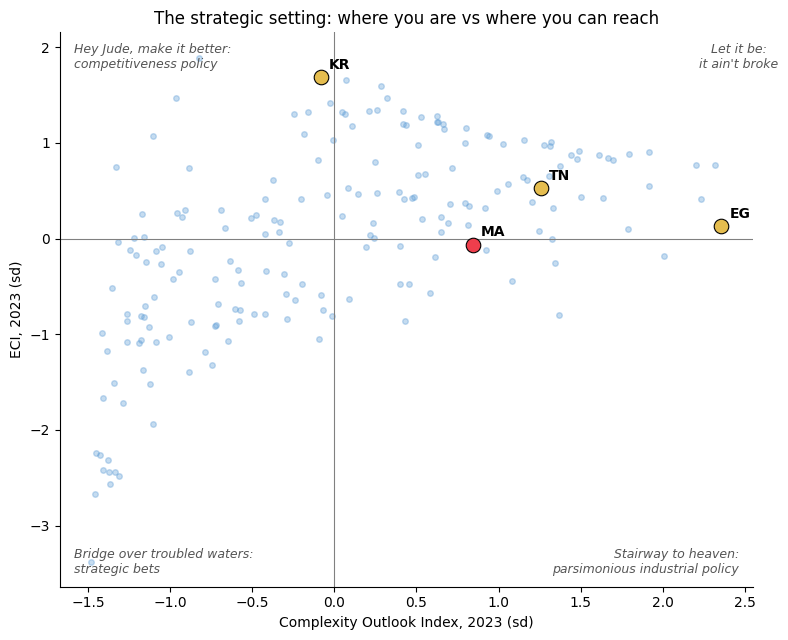

## 10. ECI over time: freeze the yardstick

Section 9 used each window's initial ECI, which raises a question every country team will want to answer on Friday: has the country's complexity risen over the last two decades? Comparing raw ECI values across years cannot answer it. Each year's index is estimated from that year's cross-section alone and standardized to mean 0 and standard deviation 1 among that year's countries, and the product scores behind it are re-estimated every year too, so the basket and the yardstick move at the same time. Growth Lab practice separates the two with a trick: freeze every product's PCI at its most recent estimate, then price each year's basket at those fixed scores. For that to be legitimate we need one property of the index, and deriving it also settles which weights are the right ones.

### The property, derived

In the binary world, a country's ECI equals the plain average of the PCI of the products it exports with RCA above 1. Our pipeline is continuous, so the question is whether ECI is still a weighted average of PCI, and with which weights. The natural guess, weighting each product by its RCA, turns out to be wrong.

Follow the package's construction, which is Day 1's with continuous weights. It first estimates the raw product score $q_p$, the eigenvector for the second-largest eigenvalue of the product-product matrix $\widetilde{M}_{pp'}$, now assembled from the presence weights $\widehat{M}_{cp} = \mathrm{RCA}_{cp} / (1 + \mathrm{RCA}_{cp})$. It then defines the raw country score as the $\widehat{M}$-weighted average of $q$ over the country's basket:

$$ k_c = \frac{\sum_p \widehat{M}_{cp} \, q_p}{\sum_p \widehat{M}_{cp}} $$

The step everything hangs on comes last. The package standardizes both vectors with the same two constants, the mean $\mu_k$ and standard deviation $\sigma_k$ of the raw country score:

$$ \mathrm{ECI}_c = \frac{k_c - \mu_k}{\sigma_k}, \qquad \mathrm{PCI}_p = \frac{q_p - \mu_k}{\sigma_k} $$

A weighted average passes through that rescaling untouched, since every term shifts by the same $\mu_k$ and divides by the same $\sigma_k$:

$$ \frac{\sum_p \widehat{M}_{cp} \, \mathrm{PCI}_p}{\sum_p \widehat{M}_{cp}} = \frac{k_c - \mu_k}{\sigma_k} = \mathrm{ECI}_c $$

So the binary property survives in the continuous world, with two corrections. The weights are $\widehat{M}$, whose cap below 1 does real work: raw RCA is unbounded, so a single hyper-specialized export with an RCA in the hundreds would drag the whole average toward its own PCI. And the denominator is the sum of the weights, where the binary version divides by a product count. One convention makes the identity exact rather than approximate: py-ecomplexity standardizes PCI with the ECI's constants, the convention the original Stata implementation set. A package that standardizes PCI by its own mean and standard deviation, as R's `economiccomplexity` does, keeps the identity up to a linear rescaling, and the R companion shows the one-line recalibration.

**Stuck? Reveal a hint (then a fuller hint).**

Hint 1. `m_hat_t1 * pci_frozen` multiplies every country's row of weights by the product scores, because pandas aligns a Series on the DataFrame's columns. You then need a sum across products (`axis=1`) on top, divided by the same sum applied to the weights alone.

Hint 2. `eci_check = (m_hat_t1 * pci_frozen).sum(axis=1) / m_hat_t1.sum(axis=1)`.

The identity makes the time series cheap. Freeze PCI at the latest year, rebuild only the first half of the pipeline for every year in the packet, exports through M-hat, and take the weighted average each year. No eigenvector is re-estimated after this point, and that is the entire point of the trick: the product scores stay put, so whatever movement you see is the basket changing, and only that.

### Predict before running

Morocco's 2001 basket against its 2023 basket, priced at the same frozen scores: did average complexity rise, fall, or hold flat? Same question for Korea, which already sat near the top of the world distribution in 2001. Commit to both answers before running the loop.

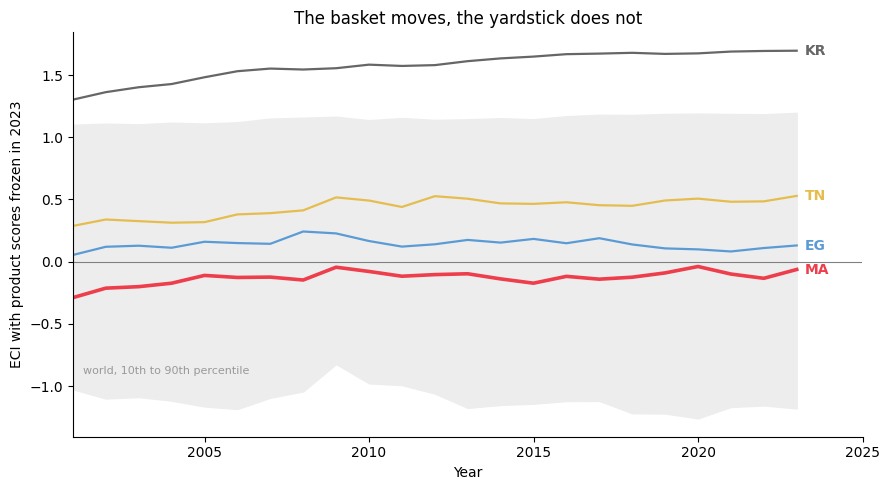

Morocco's basket, priced at fixed product scores, moved from about a third of a standard deviation below the frozen-year world average in 2001 to just under that average in 2023, so the diversification documented in section 8 reads as a real compositional upgrade. Korea keeps climbing even from the top of the distribution, visible here because nothing re-standardizes each year back to mean zero. Keep two caveats attached before this chart enters a slide deck. The exercise prices every basket at one year's scores, so in the frozen year the series equals the published index exactly (that is the self-check), and in every other year it is deliberately a different object from that year's own ECI, blind to any product whose true complexity changed over the period; freezing PCI in a different year and re-drawing the chart is a cheap robustness check for Friday. And the levels inherit Day 1's caveat: a trade-only, single-eigenvector index supports trajectories and gaps better than precise country positions.

## 11. What today's evidence does and does not say

The regressions are descriptive. Say that precisely, because the description is the whole claim. Density is not a policy lever; it moves when the basket moves. What the entry regression shows is that the capabilities already visible in a country's basket tell you where its next products came from, historically, at both the product level and the country level. Nothing today identifies what happens if a government pushes a product it is not near: Morocco's automotive bet shows such pushes can succeed, and the regression cannot tell you when they do. The growth regression inherits the same limit at the country grain, since initial ECI travels with income, institutions, and everything else a capable state does, so its coefficient is a conditional correlation and says nothing about what deliberately building complexity would do to growth. The lag removes the mechanical part of the circularity (entering a product raises density around it), and it cannot remove the deeper one: unobserved capabilities drive both density and entry. On top of that, everything inherits Day 1's caveats, since RCA > 1 is a knife edge, exports are not production, and services and the informal economy are invisible here.

### Interpret (no AI)

Below is a summary of today's session written by a chatbot. Mark every claim the analysis cannot support, then rewrite it in two sentences a minister could quote safely.

> "Our regression demonstrates that relatedness density is a key driver of export diversification: raising a product's density by one standard deviation causes an increase of several percentage points in its probability of entry. Morocco should therefore prioritize investments that increase density around strategic sectors. Since the growth regression shows that complexity raises GDP growth, these interventions will also accelerate national growth."

TODO(concept): list the overclaims, then your rewrite.

## 12. Recall: close the loop

From memory, without scrolling up:

1. Define an entry event precisely. Which two conditions, in which two years?
2. Why must density be measured in the earlier year? Name the bug you fixed.
3. What do the country and product fixed effects absorb, and name one confounder they cannot remove.
4. What pattern in the bar chart would have falsified the Principle of Relatedness?
5. What does the growth regression add that the entry regression alone cannot say?
6. ECI is a weighted average of PCI in our continuous pipeline. Which weights, which denominator, and which standardization convention make that identity exact?

TODO(concept): your answers here.

## Stretch (for fast finishers, scaffolding removed)

(a) The logit. The linear probability model is transparent and slightly wrong for a rare outcome. Rerun the entry regression as `pf.feglm("appeared ~ density_sd | loc + prod", data=..., family="logit")` and translate the coefficient into an effect on the entry probability at the base rate. How different is the story?

(b) Pool the windows. Build the same entry frame for the 2001 to 2012 window, stack it with the 2012 to 2023 one, add a window fixed effect, and see what pooling does to the precision. The growth regression in section 9 already uses this design.

(c) Break the circularity harder. Density is computed from a proximity matrix that the country's own exports helped estimate. Recompute proximity using only half the countries (drawn at random), compute density for the other half from it, and rerun the entry regression on the held-out half.

(d) The residual approach. Lecture 5's two-stage method uses the residual from section 3's cross-sectional regression (the gap between what the ecosystem implies and what the country actually does) to predict growth. Extract the residuals from `m_cross` and check whether cells that underperform their ecosystem (large negative residual) grow faster to t1.